# Исследование сервиса по аренде самоатов GoFast

Вы аналитик популярного сервиса аренды самокатов GoFast. Вам передали данные о некоторых пользователях из нескольких городов, а также об их поездках и подписках. Проанализируйте данные и проверьте некоторые гипотезы, которые могут помочь бизнесу вырасти.

**Цель исследования:**

1. **Опишите и визуализируйте общую информацию о пользователях и поездках:**
- частота встречаемости городов;
- соотношение пользователей с подпиской и без подписки;
- возраст пользователей;
- расстояние, которое пользователь преодолел за одну поездку;
- родолжительность поездок.
1. **Осуществить подсчёт выручки**
- найдите суммарное расстояние, количество поездок и суммарное время для каждого пользователя за каждый месяц.
- посчитать помесячную выручку, которую принёс каждый пользователь.
1. **Проверить гипотезы**
- тратят ли пользователи с подпиской больше времени на поездки?
- проверить превышают ли расстояние оптимальное с точки зрения износа самоката
- будет ли помесячная выручка от пользователей с подпиской по месяцам выше, чем выручка от пользователей без подписки.
- из за обновления серверов, снизилось количество обращений в техподдержку.  
  **Ход исследования**  
  Данные о пользователях получу из **/datasets/users_go.csv**, данные о поездках получу из **/datasets/rides_go.csv** и данные о подписках получу из **/datasets/subscriptions_go.csv**. О качестве данных ничего неизвестно поэтому сделаю обзор и предобработку данных.

Таким образом мое исследование пройдет в 7 этапов:

- Загрузка данных и обзор данных
- Пердобработка данныхз
- Исследовательский анализ данных
- Объединение данных
- Подсчет выручки
- проверка гипотез
- общий вывод </div>

```python
import pandas as pd
from scipy import stats as st
import matplotlib.pyplot as plt
import numpy as np
```

## Шаг: Загрузка данных

### Таблица пользователей

```python
try:
    data_users = pd.read_csv('/datasets/users_go.csv')
except:
    data_users = pd.read_csv('https://code.s3.yandex.net/datasets/users_go.csv')
```

```python
data_users.info()
```

```
<class 'pandas.core.frame.DataFrame'>
RangeIndex: 1565 entries, 0 to 1564
Data columns (total 5 columns):
 #   Column             Non-Null Count  Dtype
---  ------             --------------  -----
 0   user_id            1565 non-null   int64
 1   name               1565 non-null   object
 2   age                1565 non-null   int64
 3   city               1565 non-null   object
 4   subscription_type  1565 non-null   object
dtypes: int64(2), object(3)
memory usage: 61.3+ KB
```

```python
data_users.head(10)
```

|  | user_id | name | age | city | subscription_type |
| --- | --- | --- | --- | --- | --- |
| 0 | 1 | Кира | 22 | Тюмень | ultra |
| 1 | 2 | Станислав | 31 | Омск | ultra |
| 2 | 3 | Алексей | 20 | Москва | ultra |
| 3 | 4 | Константин | 26 | Ростов-на-Дону | ultra |
| 4 | 5 | Адель | 28 | Омск | ultra |
| 5 | 6 | Регина | 25 | Краснодар | ultra |
| 6 | 7 | Игорь | 23 | Омск | ultra |
| 7 | 8 | Юрий | 23 | Краснодар | ultra |
| 8 | 9 | Ян | 21 | Пятигорск | ultra |
| 9 | 10 | Валерий | 18 | Екатеринбург | ultra |

### Поездки

```python
try:
    data_rides = pd.read_csv('/datasets/rides_go.csv')
except:
    data_rides = pd.read_csv('https://code.s3.yandex.net/datasets/rides_go.csv')
```

```python
data_rides.info()
```

```
<class 'pandas.core.frame.DataFrame'>
RangeIndex: 18068 entries, 0 to 18067
Data columns (total 4 columns):
 #   Column    Non-Null Count  Dtype
---  ------    --------------  -----
 0   user_id   18068 non-null  int64
 1   distance  18068 non-null  float64
 2   duration  18068 non-null  float64
 3   date      18068 non-null  object
dtypes: float64(2), int64(1), object(1)
memory usage: 564.8+ KB
```

```python
data_rides.head(10)
```

|  | user_id | distance | duration | date |
| --- | --- | --- | --- | --- |
| 0 | 1 | 4409.919140 | 25.599769 | 2021-01-01 |
| 1 | 1 | 2617.592153 | 15.816871 | 2021-01-18 |
| 2 | 1 | 754.159807 | 6.232113 | 2021-04-20 |
| 3 | 1 | 2694.783254 | 18.511000 | 2021-08-11 |
| 4 | 1 | 4028.687306 | 26.265803 | 2021-08-28 |
| 5 | 1 | 2770.890808 | 16.650138 | 2021-10-09 |
| 6 | 1 | 3039.020292 | 14.927879 | 2021-10-19 |
| 7 | 1 | 2842.118050 | 23.117468 | 2021-11-06 |
| 8 | 1 | 3412.690668 | 15.238072 | 2021-11-14 |
| 9 | 1 | 748.690645 | 15.041884 | 2021-11-22 |

### Подписки

```python
try:
    data_subscriptions = pd.read_csv('/datasets/subscriptions_go.csv')
except:
    data_subscriptions = pd.read_csv('https://code.s3.yandex.net/datasets/subscriptions_go.csv')
```

```python
data_subscriptions.info()
```

```
<class 'pandas.core.frame.DataFrame'>
RangeIndex: 2 entries, 0 to 1
Data columns (total 4 columns):
 #   Column             Non-Null Count  Dtype
---  ------             --------------  -----
 0   subscription_type  2 non-null      object
 1   minute_price       2 non-null      int64
 2   start_ride_price   2 non-null      int64
 3   subscription_fee   2 non-null      int64
dtypes: int64(3), object(1)
memory usage: 192.0+ bytes
```

```python
data_subscriptions.head(10)
```

|  | subscription_type | minute_price | start_ride_price | subscription_fee |
| --- | --- | --- | --- | --- |
| 0 | free | 8 | 50 | 0 |
| 1 | ultra | 6 | 0 | 199 |

### Первичный вывод по данным

- Данные загружены
- Выведена info
- выведены первые 10 значение
- Данные корректны почти везде
- в data_rides date c некорректным типом object

## Шаг: Предобработка данных

### Проверим таблицы на пропуски

```python
#Таблица с пользователями
data_users.isna().sum()
```

```
user_id              0
name                 0
age                  0
city                 0
subscription_type    0
dtype: int64
```

```python
# Таблица с поездками
data_rides.isna().sum()
```

```
user_id     0
distance    0
duration    0
date        0
dtype: int64
```

```python
# Таблица с тарифами
data_subscriptions.isna().sum()
```

```
subscription_type    0
minute_price         0
start_ride_price     0
subscription_fee     0
dtype: int64
```

### Проверим таблицы на дубликаты

```python
# Дубликаты по пользователям
data_users.duplicated().sum()
```

```
31
```

```python
# Т.к. дубликатов не много мы их удаляем
data_users.drop_duplicates(inplace=True)
```

```python
#Повторно проверяем, что дубликаты удалены
data_users.duplicated().sum()
```

```
0
```

```python
# Дубликаты по поездкам
data_rides.duplicated().sum()
```

```
0
```

### Изменение типа данных

#### Изменис тип данных в таблице data_rides на date

```python
data_rides['date'] = pd.to_datetime(data_rides['date'], format='%Y-%m-%d')
```

```python
# Проверим произошла ли смена типа данных
data_rides['date'].head(10)
```

```
0   2021-01-01
1   2021-01-18
2   2021-04-20
3   2021-08-11
4   2021-08-28
5   2021-10-09
6   2021-10-19
7   2021-11-06
8   2021-11-14
9   2021-11-22
Name: date, dtype: datetime64[ns]
```

### Создание нового столбаца с номером месяца на основе столбца date

```python
# ПРоверка за какой год выборка данных
data_rides['date'].dt.year.unique()
```

```
array([2021])
```

```python
# Добавляем новый столбец month
data_rides['month'] = data_rides['date'].dt.month
```

```python
#Провеярем
data_rides.head(10)
```

|  | user_id | distance | duration | date | month |
| --- | --- | --- | --- | --- | --- |
| 0 | 1 | 4409.919140 | 25.599769 | 2021-01-01 | 1 |
| 1 | 1 | 2617.592153 | 15.816871 | 2021-01-18 | 1 |
| 2 | 1 | 754.159807 | 6.232113 | 2021-04-20 | 4 |
| 3 | 1 | 2694.783254 | 18.511000 | 2021-08-11 | 8 |
| 4 | 1 | 4028.687306 | 26.265803 | 2021-08-28 | 8 |
| 5 | 1 | 2770.890808 | 16.650138 | 2021-10-09 | 10 |
| 6 | 1 | 3039.020292 | 14.927879 | 2021-10-19 | 10 |
| 7 | 1 | 2842.118050 | 23.117468 | 2021-11-06 | 11 |
| 8 | 1 | 3412.690668 | 15.238072 | 2021-11-14 | 11 |
| 9 | 1 | 748.690645 | 15.041884 | 2021-11-22 | 11 |

### Выводы по предобработке данных

- Пропусков в таблица Нет
- Дубликаты были только data_users их было незначительное кол-во, они были удалены
- в таблице data_rides изменили тип данных столбца date на корректный datetime64
- Добавили новый столбец Month

## Шаг: Исследовательский анализ данных

### Частота встречаемости городов;

```python
data_users['city'].value_counts().sort_values()
```

```
Москва            168
Тюмень            180
Омск              183
Сочи              189
Краснодар         193
Ростов-на-Дону    198
Екатеринбург      204
Пятигорск         219
Name: city, dtype: int64
```

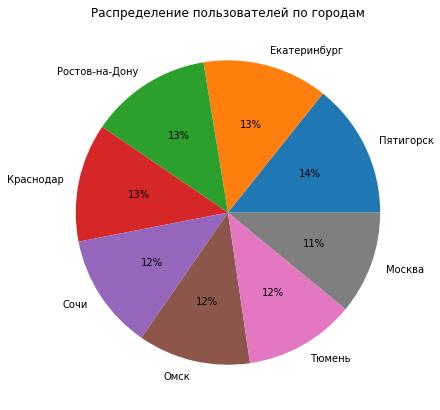

```python
data_users['city'].value_counts().plot(kind='pie',
                                       autopct='%1.0f%%',
                                       figsize=(10,7),
                                       title = 'Распределение пользователей по городам',ylabel='' )
```

### Cоотношение пользователей с подпиской и без подписки;

```python
data_users['subscription_type'].value_counts()
```

```
free     835
ultra    699
Name: subscription_type, dtype: int64
```

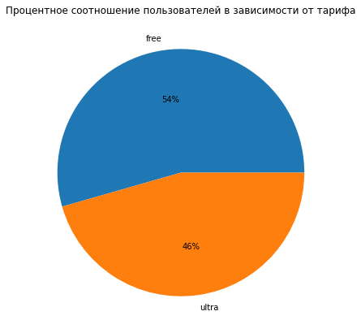

```python
data_users['subscription_type'].value_counts().plot(kind='pie',
                                                    autopct='%1.0f%%',
                                                    title='Процентное соотношение пользователей в зависимости от тарифа',
                                                    ylabel='',figsize=(7,7))
```

**Вывод:** Пользователей без подписки больше чем с платной в соотношении 54% к 46%

### Возраст пользователей;

```python
data_users['age'].sort_values()
```

```
664     12
66      12
727     12
34      12
235     13
        ..
383     38
804     38
453     38
961     39
1201    43
Name: age, Length: 1534, dtype: int64
```

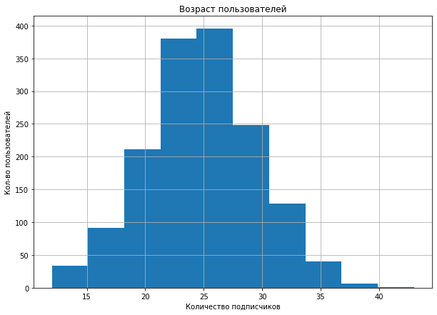

```python
data_users['age'].hist(bins=10, figsize=(10,7))
plt.grid(True)
plt.title('Возраст пользователей')
plt.xlabel('Количество подписчиков')
plt.ylabel('Кол-во пользователей')
```

**Выводы**: Возраст пользователей от 12 до 43 лет. В основном возраст пользователей от 20 до 30 лет

### Расстояние, которое пользователь преодолел за одну поездку;

```python
data_rides.head(10)
```

|  | user_id | distance | duration | date | month |
| --- | --- | --- | --- | --- | --- |
| 0 | 1 | 4409.919140 | 25.599769 | 2021-01-01 | 1 |
| 1 | 1 | 2617.592153 | 15.816871 | 2021-01-18 | 1 |
| 2 | 1 | 754.159807 | 6.232113 | 2021-04-20 | 4 |
| 3 | 1 | 2694.783254 | 18.511000 | 2021-08-11 | 8 |
| 4 | 1 | 4028.687306 | 26.265803 | 2021-08-28 | 8 |
| 5 | 1 | 2770.890808 | 16.650138 | 2021-10-09 | 10 |
| 6 | 1 | 3039.020292 | 14.927879 | 2021-10-19 | 10 |
| 7 | 1 | 2842.118050 | 23.117468 | 2021-11-06 | 11 |
| 8 | 1 | 3412.690668 | 15.238072 | 2021-11-14 | 11 |
| 9 | 1 | 748.690645 | 15.041884 | 2021-11-22 | 11 |

```python
data_rides['distance'].round(2).sort_values()
```

```
11555       0.86
9541        2.57
13690       4.33
8658        6.78
7841        7.10
          ...
17242    6724.93
17171    6760.94
15580    6908.49
16484    7066.00
16309    7211.01
Name: distance, Length: 18068, dtype: float64
```

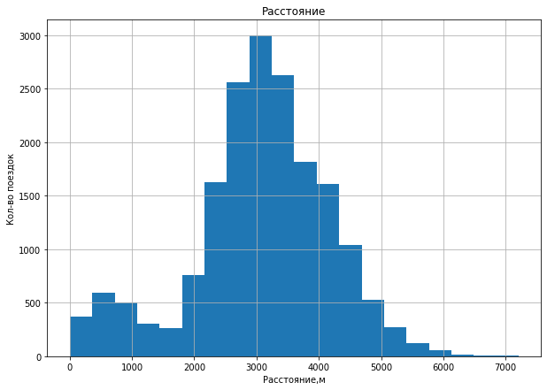

```python
data_rides['distance'].round().sort_values().hist(bins=20, figsize=(10,7))
plt.grid(True)
plt.title('Расстояние')
plt.xlabel('Расстояние,м')
plt.ylabel('Кол-во поездок')
```

### Продолжительность поездок.

```python
data_rides['duration'].round(2).sort_values()
```

```
14342     0.50
13012     0.50
8329      0.50
6883      0.50
15818     0.50
         ...
6453     38.27
1998     38.35
2623     39.53
4709     39.87
4215     40.82
Name: duration, Length: 18068, dtype: float64
```

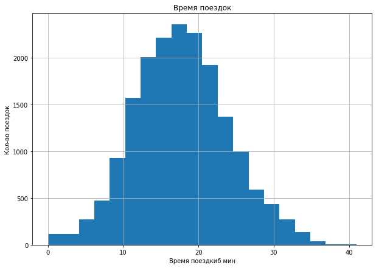

```python
data_rides['duration'].round().sort_values().hist(bins=20, figsize=(10,7))
plt.grid(True)
plt.title('Время поездок')
plt.xlabel('Время поездкиб мин')
plt.ylabel('Кол-во поездок')
```

**Вывод** Самая короткая поздка 0.5 минуты, самая длинная 40 минут. В среднем пользователи ездя по 10-25 минут.

## Шаг: Объединение данных

### Объедините данные о пользователях, поездках и подписках в один датафрейм. Для этого воспользуйтесь методом merge().

```python
data_users.shape
```

```
(1534, 5)
```

```python
data_rides.shape
```

```
(18068, 5)
```

```python
data_subscriptions.shape
```

```
(2, 4)
```

```python
data_users.head(10)
```

|  | user_id | name | age | city | subscription_type |
| --- | --- | --- | --- | --- | --- |
| 0 | 1 | Кира | 22 | Тюмень | ultra |
| 1 | 2 | Станислав | 31 | Омск | ultra |
| 2 | 3 | Алексей | 20 | Москва | ultra |
| 3 | 4 | Константин | 26 | Ростов-на-Дону | ultra |
| 4 | 5 | Адель | 28 | Омск | ultra |
| 5 | 6 | Регина | 25 | Краснодар | ultra |
| 6 | 7 | Игорь | 23 | Омск | ultra |
| 7 | 8 | Юрий | 23 | Краснодар | ultra |
| 8 | 9 | Ян | 21 | Пятигорск | ultra |
| 9 | 10 | Валерий | 18 | Екатеринбург | ultra |

```python
data_rides.head(10)
```

|  | user_id | distance | duration | date | month |
| --- | --- | --- | --- | --- | --- |
| 0 | 1 | 4409.919140 | 25.599769 | 2021-01-01 | 1 |
| 1 | 1 | 2617.592153 | 15.816871 | 2021-01-18 | 1 |
| 2 | 1 | 754.159807 | 6.232113 | 2021-04-20 | 4 |
| 3 | 1 | 2694.783254 | 18.511000 | 2021-08-11 | 8 |
| 4 | 1 | 4028.687306 | 26.265803 | 2021-08-28 | 8 |
| 5 | 1 | 2770.890808 | 16.650138 | 2021-10-09 | 10 |
| 6 | 1 | 3039.020292 | 14.927879 | 2021-10-19 | 10 |
| 7 | 1 | 2842.118050 | 23.117468 | 2021-11-06 | 11 |
| 8 | 1 | 3412.690668 | 15.238072 | 2021-11-14 | 11 |
| 9 | 1 | 748.690645 | 15.041884 | 2021-11-22 | 11 |

```python
data_subscriptions.head(10)
```

|  | subscription_type | minute_price | start_ride_price | subscription_fee |
| --- | --- | --- | --- | --- |
| 0 | free | 8 | 50 | 0 |
| 1 | ultra | 6 | 0 | 199 |

```python
# Объединим data_users с data_rides по user_id
merge_data = data_users.merge(data_rides, on='user_id')
```

```python
# Добавим к уже объединенной таблице таблицу ata_subscriptions по subscription_type
merge_data = merge_data.merge(data_subscriptions, on='subscription_type')
```

```python
# Выведем общую таблицу
merge_data
```

|  | user_id | name | age | city | subscription_type | distance | duration | date | month | minute_price | start_ride_price | subscription_fee |
| --- | --- | --- | --- | --- | --- | --- | --- | --- | --- | --- | --- | --- |
| 0 | 1 | Кира | 22 | Тюмень | ultra | 4409.919140 | 25.599769 | 2021-01-01 | 1 | 6 | 0 | 199 |
| 1 | 1 | Кира | 22 | Тюмень | ultra | 2617.592153 | 15.816871 | 2021-01-18 | 1 | 6 | 0 | 199 |
| 2 | 1 | Кира | 22 | Тюмень | ultra | 754.159807 | 6.232113 | 2021-04-20 | 4 | 6 | 0 | 199 |
| 3 | 1 | Кира | 22 | Тюмень | ultra | 2694.783254 | 18.511000 | 2021-08-11 | 8 | 6 | 0 | 199 |
| 4 | 1 | Кира | 22 | Тюмень | ultra | 4028.687306 | 26.265803 | 2021-08-28 | 8 | 6 | 0 | 199 |
| ... | ... | ... | ... | ... | ... | ... | ... | ... | ... | ... | ... | ... |
| 18063 | 1534 | Альберт | 25 | Краснодар | free | 3781.098080 | 19.822962 | 2021-11-04 | 11 | 8 | 50 | 0 |
| 18064 | 1534 | Альберт | 25 | Краснодар | free | 2840.423057 | 21.409799 | 2021-11-16 | 11 | 8 | 50 | 0 |
| 18065 | 1534 | Альберт | 25 | Краснодар | free | 3826.185507 | 18.435051 | 2021-11-18 | 11 | 8 | 50 | 0 |
| 18066 | 1534 | Альберт | 25 | Краснодар | free | 2902.308661 | 16.674362 | 2021-11-27 | 11 | 8 | 50 | 0 |
| 18067 | 1534 | Альберт | 25 | Краснодар | free | 2371.711192 | 15.893917 | 2021-12-29 | 12 | 8 | 50 | 0 |

18068 rows × 12 columns

```python
#размер результирующего датафрейма
merge_data.shape
```

```
(18068, 12)
```

### Создайте ещё два датафрейма из датафрейма, созданного на этапе 4.1:

#### C данными о пользователях без подписки;

```python
free_sub = merge_data.query('subscription_type == "free"')
```

```python
free_sub
```

|  | user_id | name | age | city | subscription_type | distance | duration | date | month | minute_price | start_ride_price | subscription_fee |
| --- | --- | --- | --- | --- | --- | --- | --- | --- | --- | --- | --- | --- |
| 6500 | 700 | Айдар | 22 | Омск | free | 2515.690719 | 14.944286 | 2021-01-02 | 1 | 8 | 50 | 0 |
| 6501 | 700 | Айдар | 22 | Омск | free | 846.932642 | 16.234663 | 2021-02-01 | 2 | 8 | 50 | 0 |
| 6502 | 700 | Айдар | 22 | Омск | free | 4004.434142 | 20.016628 | 2021-02-04 | 2 | 8 | 50 | 0 |
| 6503 | 700 | Айдар | 22 | Омск | free | 1205.911290 | 9.782872 | 2021-02-10 | 2 | 8 | 50 | 0 |
| 6504 | 700 | Айдар | 22 | Омск | free | 3047.379435 | 17.427673 | 2021-02-14 | 2 | 8 | 50 | 0 |
| ... | ... | ... | ... | ... | ... | ... | ... | ... | ... | ... | ... | ... |
| 18063 | 1534 | Альберт | 25 | Краснодар | free | 3781.098080 | 19.822962 | 2021-11-04 | 11 | 8 | 50 | 0 |
| 18064 | 1534 | Альберт | 25 | Краснодар | free | 2840.423057 | 21.409799 | 2021-11-16 | 11 | 8 | 50 | 0 |
| 18065 | 1534 | Альберт | 25 | Краснодар | free | 3826.185507 | 18.435051 | 2021-11-18 | 11 | 8 | 50 | 0 |
| 18066 | 1534 | Альберт | 25 | Краснодар | free | 2902.308661 | 16.674362 | 2021-11-27 | 11 | 8 | 50 | 0 |
| 18067 | 1534 | Альберт | 25 | Краснодар | free | 2371.711192 | 15.893917 | 2021-12-29 | 12 | 8 | 50 | 0 |

11568 rows × 12 columns

```python
free_sub.shape
```

```
(11568, 12)
```

**Визуализируем информацию о расстоянии на бесплатном тарифе**

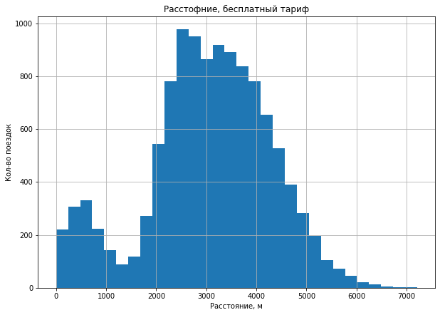

```python
free_sub['distance'].hist(bins=30,figsize=(10,7))
plt.grid(True)
plt.title('Расстофние, бесплатный тариф')
plt.xlabel('Расстояние, м')
plt.ylabel('Кол-во поездок')
```

```python
free_sub['distance'].round(2).sort_values()
```

```
11555       0.86
9541        2.57
13690       4.33
8658        6.78
7841        7.10
          ...
17242    6724.93
17171    6760.94
15580    6908.49
16484    7066.00
16309    7211.01
Name: distance, Length: 11568, dtype: float64
```

```python
free_sub['distance'].median().round(2)
```

```
3114.65
```

**Вывод:** Минимальное расстояние, которое проехали пользователи в бесплатном тарифе 0.86 м и максимальная 7211м. Основная часть поездок занимает от 2200 до 4500 метров. Медиана 3114 метра. Поездки на расстояние более 5 км редки. Однако на гистограмме видно, что некоторая часть пользователей использует самокаты для коротких поездок - до 1500 м.

**Визуализируем информацию о времени на бесплатном тарифе**

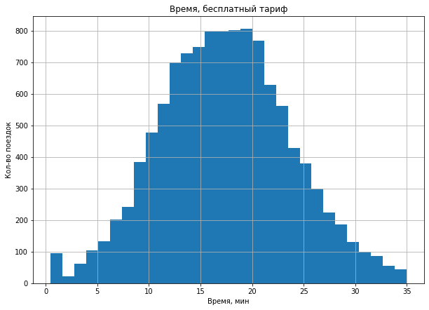

```python
free_sub['duration'].hist(bins=30,figsize=(10,7))
plt.grid(True)
plt.title('Время, бесплатный тариф')
plt.xlabel('Время, мин')
plt.ylabel('Кол-во поездок')
```

```python
free_sub['duration'].round().sort_values()
```

```
11853     0.0
15015     0.0
17505     0.0
9135      0.0
12967     0.0
         ...
11824    35.0
10385    35.0
7685     35.0
13997    35.0
8517     35.0
Name: duration, Length: 11568, dtype: float64
```

```python
free_sub['duration'].median().round()
```

```
17.0
```

**Вывод:** В бесплаьном тарифе минимум 0 мину и максимум 35 минут. 0 минут по каким то причинам пользователь отказался от поездки, возможно из за поломки. Медиана 17 минут.

#### C данными о пользователях с подпиской.

```python
ultra_sub = merge_data.query('subscription_type == "ultra"')
```

```python
ultra_sub
```

|  | user_id | name | age | city | subscription_type | distance | duration | date | month | minute_price | start_ride_price | subscription_fee |
| --- | --- | --- | --- | --- | --- | --- | --- | --- | --- | --- | --- | --- |
| 0 | 1 | Кира | 22 | Тюмень | ultra | 4409.919140 | 25.599769 | 2021-01-01 | 1 | 6 | 0 | 199 |
| 1 | 1 | Кира | 22 | Тюмень | ultra | 2617.592153 | 15.816871 | 2021-01-18 | 1 | 6 | 0 | 199 |
| 2 | 1 | Кира | 22 | Тюмень | ultra | 754.159807 | 6.232113 | 2021-04-20 | 4 | 6 | 0 | 199 |
| 3 | 1 | Кира | 22 | Тюмень | ultra | 2694.783254 | 18.511000 | 2021-08-11 | 8 | 6 | 0 | 199 |
| 4 | 1 | Кира | 22 | Тюмень | ultra | 4028.687306 | 26.265803 | 2021-08-28 | 8 | 6 | 0 | 199 |
| ... | ... | ... | ... | ... | ... | ... | ... | ... | ... | ... | ... | ... |
| 6495 | 699 | Оксана | 22 | Москва | ultra | 3973.046497 | 24.671163 | 2021-08-29 | 8 | 6 | 0 | 199 |
| 6496 | 699 | Оксана | 22 | Москва | ultra | 3288.702563 | 15.892886 | 2021-09-12 | 9 | 6 | 0 | 199 |
| 6497 | 699 | Оксана | 22 | Москва | ultra | 3076.159348 | 14.389525 | 2021-09-26 | 9 | 6 | 0 | 199 |
| 6498 | 699 | Оксана | 22 | Москва | ultra | 4707.845501 | 15.839579 | 2021-10-17 | 10 | 6 | 0 | 199 |
| 6499 | 699 | Оксана | 22 | Москва | ultra | 3202.890770 | 25.217345 | 2021-12-03 | 12 | 6 | 0 | 199 |

6500 rows × 12 columns

```python
ultra_sub
```

|  | user_id | name | age | city | subscription_type | distance | duration | date | month | minute_price | start_ride_price | subscription_fee |
| --- | --- | --- | --- | --- | --- | --- | --- | --- | --- | --- | --- | --- |
| 0 | 1 | Кира | 22 | Тюмень | ultra | 4409.919140 | 25.599769 | 2021-01-01 | 1 | 6 | 0 | 199 |
| 1 | 1 | Кира | 22 | Тюмень | ultra | 2617.592153 | 15.816871 | 2021-01-18 | 1 | 6 | 0 | 199 |
| 2 | 1 | Кира | 22 | Тюмень | ultra | 754.159807 | 6.232113 | 2021-04-20 | 4 | 6 | 0 | 199 |
| 3 | 1 | Кира | 22 | Тюмень | ultra | 2694.783254 | 18.511000 | 2021-08-11 | 8 | 6 | 0 | 199 |
| 4 | 1 | Кира | 22 | Тюмень | ultra | 4028.687306 | 26.265803 | 2021-08-28 | 8 | 6 | 0 | 199 |
| ... | ... | ... | ... | ... | ... | ... | ... | ... | ... | ... | ... | ... |
| 6495 | 699 | Оксана | 22 | Москва | ultra | 3973.046497 | 24.671163 | 2021-08-29 | 8 | 6 | 0 | 199 |
| 6496 | 699 | Оксана | 22 | Москва | ultra | 3288.702563 | 15.892886 | 2021-09-12 | 9 | 6 | 0 | 199 |
| 6497 | 699 | Оксана | 22 | Москва | ultra | 3076.159348 | 14.389525 | 2021-09-26 | 9 | 6 | 0 | 199 |
| 6498 | 699 | Оксана | 22 | Москва | ultra | 4707.845501 | 15.839579 | 2021-10-17 | 10 | 6 | 0 | 199 |
| 6499 | 699 | Оксана | 22 | Москва | ultra | 3202.890770 | 25.217345 | 2021-12-03 | 12 | 6 | 0 | 199 |

6500 rows × 12 columns

**Визуализируем информацию о расстоянии на платном тарифе**

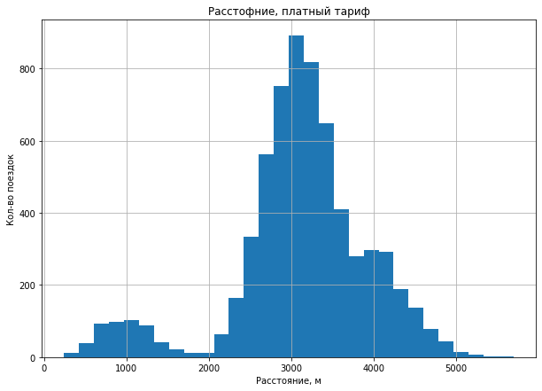

```python
ultra_sub['distance'].hist(bins=30,figsize=(10,7))
plt.grid(True)
plt.title('Расстофние, платный тариф')
plt.xlabel('Расстояние, м')
plt.ylabel('Кол-во поездок')
```

```python
ultra_sub['distance'].round(2).sort_values()
```

```
1213     244.21
5952     266.12
2656     280.96
463      307.53
2422     327.87
         ...
32      5335.21
2294    5371.48
4692    5391.97
4136    5419.68
6312    5699.77
Name: distance, Length: 6500, dtype: float64
```

```python
ultra_sub['distance'].median().round()
```

```
3149.0
```

**Вывод:** Минимальная поездка в платном тарифе 244 м и макимальная 5700. Основная часть поездок занимает от 2500 до 3500 метров. Медиана 3149 метра. Поездки на расстояние более 5 км редки. Однако на гистограмме видно, что некоторая часть пользователей использует самокаты для коротких поездок - до 1500 м.

**Визуализируем информацию о времени на платном тарифе**

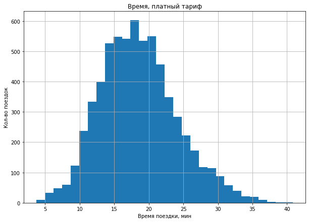

```python
ultra_sub['duration'].hist(bins=30,figsize=(10,7))
plt.grid(True)
plt.title('Время, платный тариф')
plt.xlabel('Время поездки, мин')
plt.ylabel('Кол-во поездок')
```

```python
ultra_sub['duration'].round().sort_values()
```

```
4148     4.0
3158     4.0
5952     4.0
1843     4.0
2174     4.0
        ...
6453    38.0
1998    38.0
2623    40.0
4709    40.0
4215    41.0
Name: duration, Length: 6500, dtype: float64
```

```python
ultra_sub['duration'].median().round()
```

```
18.0
```

**Вывод:** В платном тарифе минимум 4 минуты использовали и максимум 41 минут. Медиана 18 минут.

## Шаг: Подсчёт выручки

### Создайте датафрейм с агрегированными данными о поездках на основе датафрейма с объединёнными данными из шага 4: найдите суммарное расстояние, количество поездок и суммарное время для каждого пользователя за каждый месяц.

```python
merge_data.isna().sum()
```

```
user_id              0
name                 0
age                  0
city                 0
subscription_type    0
distance             0
duration             0
date                 0
month                0
minute_price         0
start_ride_price     0
subscription_fee     0
dtype: int64
```

```python
merge_data.head(10)
```

|  | user_id | name | age | city | subscription_type | distance | duration | date | month | minute_price | start_ride_price | subscription_fee |
| --- | --- | --- | --- | --- | --- | --- | --- | --- | --- | --- | --- | --- |
| 0 | 1 | Кира | 22 | Тюмень | ultra | 4409.919140 | 25.599769 | 2021-01-01 | 1 | 6 | 0 | 199 |
| 1 | 1 | Кира | 22 | Тюмень | ultra | 2617.592153 | 15.816871 | 2021-01-18 | 1 | 6 | 0 | 199 |
| 2 | 1 | Кира | 22 | Тюмень | ultra | 754.159807 | 6.232113 | 2021-04-20 | 4 | 6 | 0 | 199 |
| 3 | 1 | Кира | 22 | Тюмень | ultra | 2694.783254 | 18.511000 | 2021-08-11 | 8 | 6 | 0 | 199 |
| 4 | 1 | Кира | 22 | Тюмень | ultra | 4028.687306 | 26.265803 | 2021-08-28 | 8 | 6 | 0 | 199 |
| 5 | 1 | Кира | 22 | Тюмень | ultra | 2770.890808 | 16.650138 | 2021-10-09 | 10 | 6 | 0 | 199 |
| 6 | 1 | Кира | 22 | Тюмень | ultra | 3039.020292 | 14.927879 | 2021-10-19 | 10 | 6 | 0 | 199 |
| 7 | 1 | Кира | 22 | Тюмень | ultra | 2842.118050 | 23.117468 | 2021-11-06 | 11 | 6 | 0 | 199 |
| 8 | 1 | Кира | 22 | Тюмень | ultra | 3412.690668 | 15.238072 | 2021-11-14 | 11 | 6 | 0 | 199 |
| 9 | 1 | Кира | 22 | Тюмень | ultra | 748.690645 | 15.041884 | 2021-11-22 | 11 | 6 | 0 | 199 |

```python
merge_data['duration'] = np.ceil(merge_data['duration'])
```

```python
total_data = pd.pivot_table(merge_data,
                           index=['month', 'user_id'],
                           values = ['distance', 'duration', 'name', 'subscription_type'],
                           aggfunc = {'distance': sum,
                                      'duration' : sum,
                                      'name' : len,
                                      'subscription_type' : min})
```

```python
total_data['duration'] = np.ceil(total_data['duration'])
```

```python
total_data.rename(columns = {'name' : 'count_trips'}, inplace = True)
```

```python
total_data.sort_values(by='user_id', ascending=True).head(20)
```

| month | user_id | distance | duration | count_trips | subscription_type |
| --- | --- | --- | --- | --- | --- |
| 1 | 1 | 7027.511294 | 42.0 | 2 | ultra |
| 12 | 1 | 6751.629942 | 28.0 | 2 | ultra |
| 11 | 1 | 7003.499363 | 56.0 | 3 | ultra |
| 10 | 1 | 5809.911100 | 32.0 | 2 | ultra |
| 4 | 1 | 754.159807 | 7.0 | 1 | ultra |
| 8 | 1 | 6723.470560 | 46.0 | 2 | ultra |
| 12 | 2 | 3828.248580 | 12.0 | 1 | ultra |
| 3 | 2 | 10187.723006 | 63.0 | 3 | ultra |
| 10 | 2 | 2824.636598 | 19.0 | 1 | ultra |
| 8 | 2 | 923.007439 | 7.0 | 1 | ultra |
| 7 | 2 | 6780.722964 | 48.0 | 2 | ultra |
| 6 | 2 | 3255.338202 | 14.0 | 1 | ultra |
| 4 | 2 | 6164.381824 | 40.0 | 2 | ultra |
| 2 | 3 | 5421.152016 | 39.0 | 2 | ultra |
| 7 | 3 | 10919.595403 | 67.0 | 3 | ultra |
| 5 | 3 | 9064.026918 | 63.0 | 3 | ultra |
| 1 | 3 | 3061.777147 | 13.0 | 1 | ultra |
| 4 | 3 | 2956.651632 | 21.0 | 1 | ultra |
| 9 | 3 | 2891.012822 | 23.0 | 1 | ultra |
| 12 | 3 | 2593.381928 | 13.0 | 1 | ultra |

### В этот же датафрейм добавьте столбец с помесячной выручкой, которую принёс каждый пользователь. Для этого обратитесь к информации об условиях оплаты для подписчиков и тех, у кого нет подписки. Продолжительность каждой поездки в каждой строке исходного датафрейма для подсчёта стоимости округляется до следующего целого числа: например, значения 25.3, 25.5 26.0 должны быть преобразованы к 26.

**Добавим столбец с помесячной выручкой**

```python
def revenue(row):
    if row['subscription_type'] == 'ultra':
        return 6 * row['duration'] + 199
    elif row['subscription_type'] == 'free':
        return 8 * row['duration'] + 50 * row['count_trips']
    else:
        return 'Not such sub'
```

```python
total_data['revenue_per_month'] = total_data.apply(revenue, axis=1)
```

```python
total_data.head(10)
```

| month | user_id | distance | duration | count_trips | subscription_type | revenue_per_month |
| --- | --- | --- | --- | --- | --- | --- |
| 1 | 1 | 7027.511294 | 42.0 | 2 | ultra | 451.0 |
|  | 3 | 3061.777147 | 13.0 | 1 | ultra | 277.0 |
|  | 5 | 3914.646990 | 13.0 | 1 | ultra | 277.0 |
|  | 7 | 6478.080979 | 28.0 | 2 | ultra | 367.0 |
|  | 12 | 3577.151148 | 33.0 | 1 | ultra | 397.0 |
|  | 13 | 6687.987446 | 42.0 | 2 | ultra | 451.0 |
|  | 14 | 7699.643820 | 35.0 | 2 | ultra | 409.0 |
|  | 15 | 4187.621459 | 39.0 | 1 | ultra | 433.0 |
|  | 20 | 3516.719208 | 29.0 | 1 | ultra | 373.0 |
|  | 22 | 3058.692225 | 13.0 | 1 | ultra | 277.0 |

```python
total_data['revenue_per_month'].sum()
```

```
3878641.0
```

**Вывод:**

- Создали новый датафрейм с агрегированными данными (total_data) на основе датафрейма с объединенными данными (merge_data).
- Нашли суммарное расстояние, количество поездок и суммарное время для каждого пользователя за каждый меся
- Также добавили столбец с помесячной выручкой, которую принес каждый пользователь.

## Шаг: Проверка гипотез

### Важно понять, тратят ли пользователи с подпиской больше времени на поездки? Если да, то пользователи с подпиской могут быть «выгоднее» для компании. Проверьте гипотезу. Используйте исходные данные о продолжительности каждой сессии — отдельно для подписчиков и тех, у кого нет подписки.

- H0 - Время по подписке = время без подписки
- H1 - Время по подписке > время без подписки

```python
ultra = ultra_sub['duration']
free = free_sub['duration']
alpha = 0.05
results = st.ttest_ind(ultra, free, alternative='greater')
print('p-значение:', results.pvalue)
if results.pvalue < alpha:
    print('Отвергаем нулевую гипотезу')
else:
    print('Не получилось отвергнуть нулевую гипотеpe')
```

```
p-значение: 1.2804098316645618e-34
Отвергаем нулевую гипотезу
```

**Вывод:** Пользователи с подпиской тратят больше времени на поездки

### Расстояние одной поездки в 3130 метров — оптимальное с точки зрения износа самоката. Можно ли сказать, что расстояние, которое проезжают пользователи с подпиской за одну поездку, не превышает 3130 метров? Проверьте гипотезу и сделайте выводы.

- H0 - Расстояние одной поездки = 3130 метров по подписке
- H1 - Расстояние одной поездки > 3130 метров по подписке

```python
ultra_dist = ultra_sub['distance']
our_dist = 3130
alpha = 0.05
results = st.ttest_1samp(ultra_dist,
                        our_dist,
                        alternative='greater')
print('p-значение', results.pvalue)

if results.pvalue < alpha:
    print('Отвергаем нулевую гипотезу')
else:
    print('Не получилось отвергнуть нулевую гипотезу')
```

```
p-значение 0.9195368847849785
Не получилось отвергнуть нулевую гипотезу
```

**Вывод:** Мы не можем утверждать, что по подписке ultra пользователи проезжают больше 3130 метров

### Проверьте гипотезу о том, будет ли помесячная выручка от пользователей с подпиской по месяцам выше, чем выручка от пользователей без подписки. Сделайте вывод.

- H0 - Выручка по подписке = выручка без подписки
- H1 - Выручка по подписке > Вычручка без подписки

```python
ultre_reven = total_data.loc[total_data.subscription_type == 'ultra','revenue_per_month']
free_reven = total_data.loc[total_data.subscription_type == 'free','revenue_per_month' ]
alpha = 0.05
results = st.ttest_ind(ultre_reven,
                      free_reven,
                      alternative='greater')

print('p-значение', results.pvalue)

if results.pvalue < alpha:
    print('Отвергаем нулевую гипотезу')
else:
    print('Не получилось отвергнуть нулевую гипотезу')
```

```
p-значение 1.8850394384715216e-31
Отвергаем нулевую гипотезу
```

**Вывод:** По подписку ultra ежемесячная выручка с пользователей выше чем по подписке free

### Представьте такую ситуацию: техническая команда сервиса обновила сервера, с которыми взаимодействует мобильное приложение. Она надеется, что из-за этого количество обращений в техподдержку значимо снизилось. Некоторый файл содержит для каждого пользователя данные о количестве обращений до обновления и после него. Какой тест вам понадобился бы для проверки этой гипотезы?

**Ответ:** Нам понеадобится тест "Гипотеза о равенстве средних для зависимых (парных) выборок", где

- H0: μ1 = μ2
- H1: μ1 != μ2
- где μ1 и μ2 - средние значения количество обращений в техподдержку до и после изменения. Нам понадобился бы метод **scipy.stats.ttest_rel()**

## Шаг : Общий вывод

### Загрузили 3 датафрема:

- Таблица пользователей (users_go.csv)
- Таблица поездок (rides_go.csv)
- Таблица подписок (subscriptions_go.csv)

### Провели предобработку данных

- Проверили таблицы на пропуски (не было)
- Проверили таблицы на дубликаты (из таблицы users удалили 31)
- Изменили тип данных date
- создали новый столбец month на основе даты

### Объединение данных

- Объединили данные о пользователях, поездках и подписках в один датафрейм
- Создали еще 2 дата фрейма в зависимости от подписки (free_sub, ultra_sub)
- Визуализировал данные о времени и длительности поездок в зависимости от подписок
- Создали новый датафрейм с агрегированными данными
- Нашли суммарное расстояние, количество поездок и суммарное время для каждого пользователя за каждый месяц
- Также добавили столбец с помесячной выручкой, которую принес каждый пользователь.